# DS Minor: Lab 03 – igraph

#### Термины и понятия

Для повторения

- граф (graph)
- вершина, узел (node)
- ребро (edge)
- ориентированные (направленные) / неориентированные графы (directed / undirected graph)
- список ребер (edgelist)
- матрица смежности (adjacency matrix)

#### Инструмент

Мы будем работать с пакетом `igraph` для создания и работы с направленными и ненаправленными графами (http://igraph.org/r/)

```r
library(igraph)
```

### Создание графа

Граф состоит из набора вершин и набора ребер. Один из способов его задания – определить список ребер **edgelist**, т.е. список пар связанных вершин.

Создадим направленный граф с 4 вершинами и 5 ребрами: 1 to 2, 1 to 3, 3 to 4, 3 to 2, and 2 to 4.

```r
exampleGr <- make_graph(c(1,2, 1,3, 3,4, 3,2, 2,4), directed = TRUE)
```

Результат вызова функции `print()` – описание созданного объекта

```r
exampleGr
```

```
## IGRAPH D--- 4 5 --
## + edges:
## [1] 1->2 1->3 3->4 3->2 2->4
```

Нарисовать граф можно с помощью функции `plot()`:

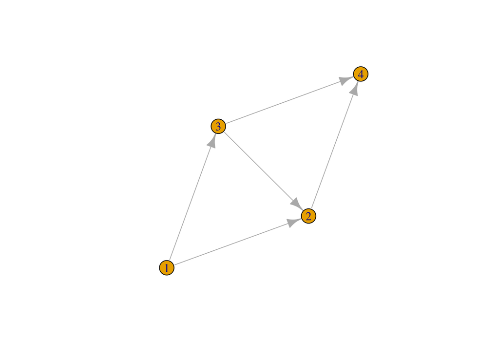

```r
plot(exampleGr)
```

Вершины не обязательно должны быть числами, это могут быть любые имена:

```r
exampleGraph <- make_graph(c("M","F", "M","L", "F","L", "E","M", "F","S", "S","M"), directed = F)
exampleGraph
```

```
## IGRAPH UN-- 5 6 --
## + attr: name (v/c)
## + edges (vertex names):
## [1] M--F M--L F--L M--E F--S M--S
```

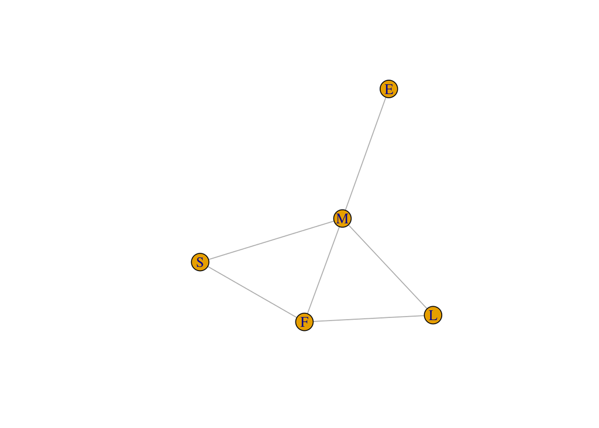

```r
plot(exampleGraph)
```

```r
V(exampleGraph)
```

```
## + 5/5 vertices, named:
## [1] M F L E S
```

#### Загрузка графа

Мы рассмотрели пример создания графа вручную, но в большинстве случаев мы будем загружать их из файлов некоторого формата. `igraph` позволяет использовать многие форматы файлов.

##### Список ребер

`graph.data.frame` (или `graph_from_data_frame`) создает граф igraph из таблицы данных (data frame), первые два столбца которого рассматриваются как список ребер (начало - конец), остальные – как дополнительные свойства ребер.

Рассмотрим искусственную социальную сеть *Krackhardt’s kite*.

```r
edgelist <- read.csv("~/shared/minor2_2016/2-datatech/lab03-igraph/kite.csv")
head(edgelist)
```

```
##   V1 V2
## 1  A  B
## 2  A  C
## 3  A  D
## 4  A  F
## 5  B  D
## 6  B  E
```

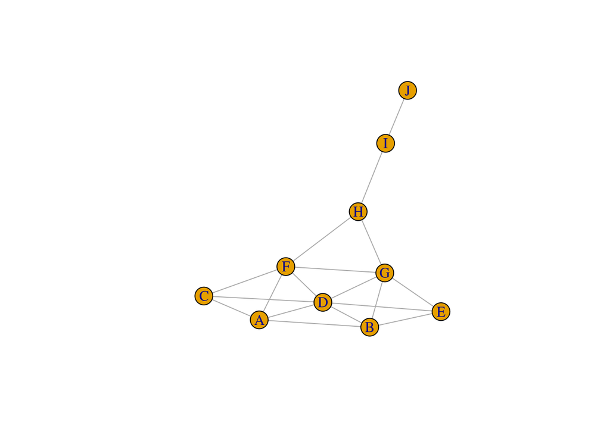

```r
kite <- graph.data.frame(edgelist, directed = FALSE)
plot(kite)
```

##### Матрица смежности (Adjacency matrix)

Еще одно представление графа – **матрица смежности** (adjacency matrix), т.е. матрица |V|x|V|, где |V| – число вершин, а элемент в i-ой строке и j-ом столбце равен 1, если есть связь между вершиной i и вершиной j, и 0 в противном случае.

Рассмотрим отношения между семьями Флоренции (Renaissance Florentine families collected by John Padgett from historical documents). Связь – брачные договоры.

```r
adjFlorence <- read.csv("~/shared/minor2_2016/2-datatech/lab03-igraph/florentineFamily.csv")
rownames(adjFlorence) <- names(adjFlorence)

adjFlorence <- as.matrix.data.frame(adjFlorence)
```

Матрица смежности

```r
pander::pandoc.table(adjFlorence, split.tables = Inf)
```

|  | Acciaiuol | Albizzi | Barbadori | Bischeri | Castellan | Ginori | Guadagni | Lambertes | Medici | Pazzi | Peruzzi | Pucci | Ridolfi | Salviati | Strozzi | Tornabuon |
| --- | --- | --- | --- | --- | --- | --- | --- | --- | --- | --- | --- | --- | --- | --- | --- | --- |
| **Acciaiuol** | 0 | 0 | 0 | 0 | 0 | 0 | 0 | 0 | 1 | 0 | 0 | 0 | 0 | 0 | 0 | 0 |
| **Albizzi** | 0 | 0 | 0 | 0 | 0 | 1 | 1 | 0 | 1 | 0 | 0 | 0 | 0 | 0 | 0 | 0 |
| **Barbadori** | 0 | 0 | 0 | 0 | 1 | 0 | 0 | 0 | 1 | 0 | 0 | 0 | 0 | 0 | 0 | 0 |
| **Bischeri** | 0 | 0 | 0 | 0 | 0 | 0 | 1 | 0 | 0 | 0 | 1 | 0 | 0 | 0 | 1 | 0 |
| **Castellan** | 0 | 0 | 1 | 0 | 0 | 0 | 0 | 0 | 0 | 0 | 1 | 0 | 0 | 0 | 1 | 0 |
| **Ginori** | 0 | 1 | 0 | 0 | 0 | 0 | 0 | 0 | 0 | 0 | 0 | 0 | 0 | 0 | 0 | 0 |
| **Guadagni** | 0 | 1 | 0 | 1 | 0 | 0 | 0 | 1 | 0 | 0 | 0 | 0 | 0 | 0 | 0 | 1 |
| **Lambertes** | 0 | 0 | 0 | 0 | 0 | 0 | 1 | 0 | 0 | 0 | 0 | 0 | 0 | 0 | 0 | 0 |
| **Medici** | 1 | 1 | 1 | 0 | 0 | 0 | 0 | 0 | 0 | 0 | 0 | 0 | 1 | 1 | 0 | 1 |
| **Pazzi** | 0 | 0 | 0 | 0 | 0 | 0 | 0 | 0 | 0 | 0 | 0 | 0 | 0 | 1 | 0 | 0 |
| **Peruzzi** | 0 | 0 | 0 | 1 | 1 | 0 | 0 | 0 | 0 | 0 | 0 | 0 | 0 | 0 | 1 | 0 |
| **Pucci** | 0 | 0 | 0 | 0 | 0 | 0 | 0 | 0 | 0 | 0 | 0 | 0 | 0 | 0 | 0 | 0 |
| **Ridolfi** | 0 | 0 | 0 | 0 | 0 | 0 | 0 | 0 | 1 | 0 | 0 | 0 | 0 | 0 | 1 | 1 |
| **Salviati** | 0 | 0 | 0 | 0 | 0 | 0 | 0 | 0 | 1 | 1 | 0 | 0 | 0 | 0 | 0 | 0 |
| **Strozzi** | 0 | 0 | 0 | 1 | 1 | 0 | 0 | 0 | 0 | 0 | 1 | 0 | 1 | 0 | 0 | 0 |
| **Tornabuon** | 0 | 0 | 0 | 0 | 0 | 0 | 1 | 0 | 1 | 0 | 0 | 0 | 1 | 0 | 0 | 0 |

Создание графа по матрице (`graph.adjacency` или `graph_from_adjacency_matrix`)

```r
florentine <- graph.adjacency(adjmatrix = adjFlorence, mode = "undirected")
```

Функции `V()` и `E()` выдают список вершин и ребер соответственно.

```r
V(florentine)
```

```
## + 16/16 vertices, named:
##  [1] Acciaiuol Albizzi   Barbadori Bischeri  Castellan Ginori    Guadagni
##  [8] Lambertes Medici    Pazzi     Peruzzi   Pucci     Ridolfi   Salviati
## [15] Strozzi   Tornabuon
```

```r
E(florentine)
```

```
## + 20/20 edges (vertex names):
##  [1] Acciaiuol--Medici    Albizzi  --Ginori    Albizzi  --Guadagni
##  [4] Albizzi  --Medici    Barbadori--Castellan Barbadori--Medici
##  [7] Bischeri --Guadagni  Bischeri --Peruzzi   Bischeri --Strozzi
## [10] Castellan--Peruzzi   Castellan--Strozzi   Guadagni --Lambertes
## [13] Guadagni --Tornabuon Medici   --Ridolfi   Medici   --Salviati
## [16] Medici   --Tornabuon Pazzi    --Salviati  Peruzzi  --Strozzi
## [19] Ridolfi  --Strozzi   Ridolfi  --Tornabuon
```

Для получения числа вершин и ребер в графе можно использовать функции `vcount()` и `ecount()`

```r
vcount(florentine)
```

```
## [1] 16
```

```r
ecount(florentine)
```

```
## [1] 20
```

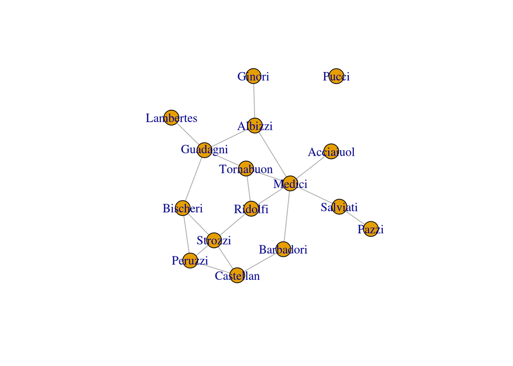

```r
plot(florentine)
```

#### Другие форматы файлов

`igraph` позволяет читать и файлы других форматов, например, файл *Pajek*. Подробности и другие форматы в `?read.graph()`

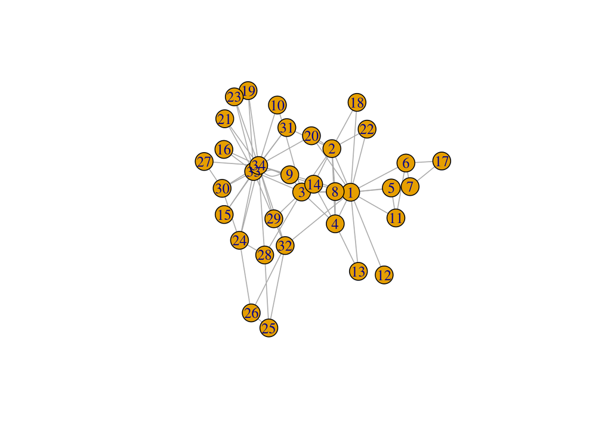

```r
karate <- read.graph("~/shared/minor2_2016/2-datatech/lab03-igraph/karate.net", format="pajek")
plot(karate)
```

Уже загруженный граф можно посмотреть в любом представлении, например, в виде матрицы.

```r
adjKarate <- get.adjacency(karate, sparse = FALSE)
pander::pandoc.table(adjKarate, split.tables = Inf)
```

[output not shown]

### Рисование графа

В пакете `igraph` много параметров для визуализации графов. Более подробно можно посмотреть в `?igraph.plotting`.

Можно менять цвета, размеры, подписи, фон и т.д., чтобы получить именно тот вид графа, что нужен. Существует два способа определения этих параметров.

Первый – указать их в функции `plot`:

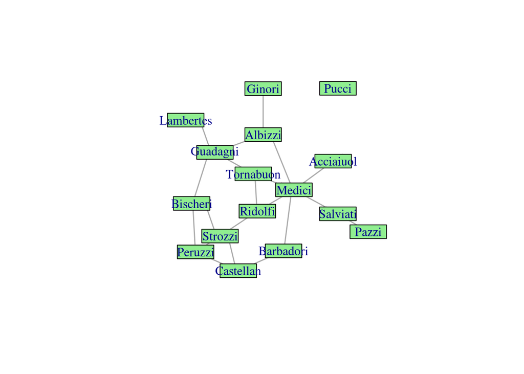

```r
plot(florentine,
     vertex.color = "lightgreen",
     vertex.size = 40,
     vertex.shape = "rectangle",
     edge.width = 1.5)
```

Второй способ – задать нужные значения как свойства вершин или ребер.

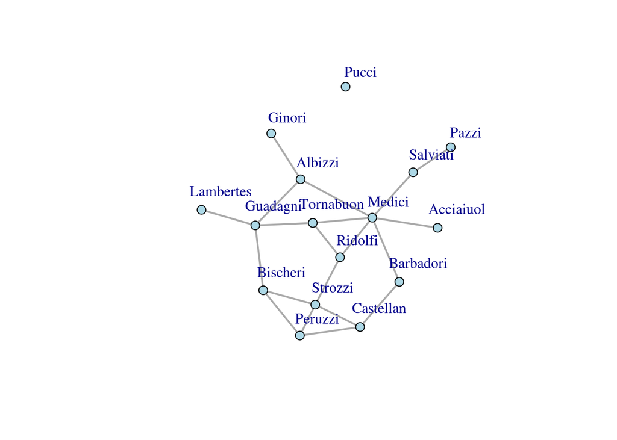

```r
V(florentine)$color = "lightblue"
V(florentine)$size = 7
V(florentine)$label.dist = 0.9 # labels outside the circles
E(florentine)$width = 2
plot(florentine)
```

Еще один параметр визуализации – укладка (layout)

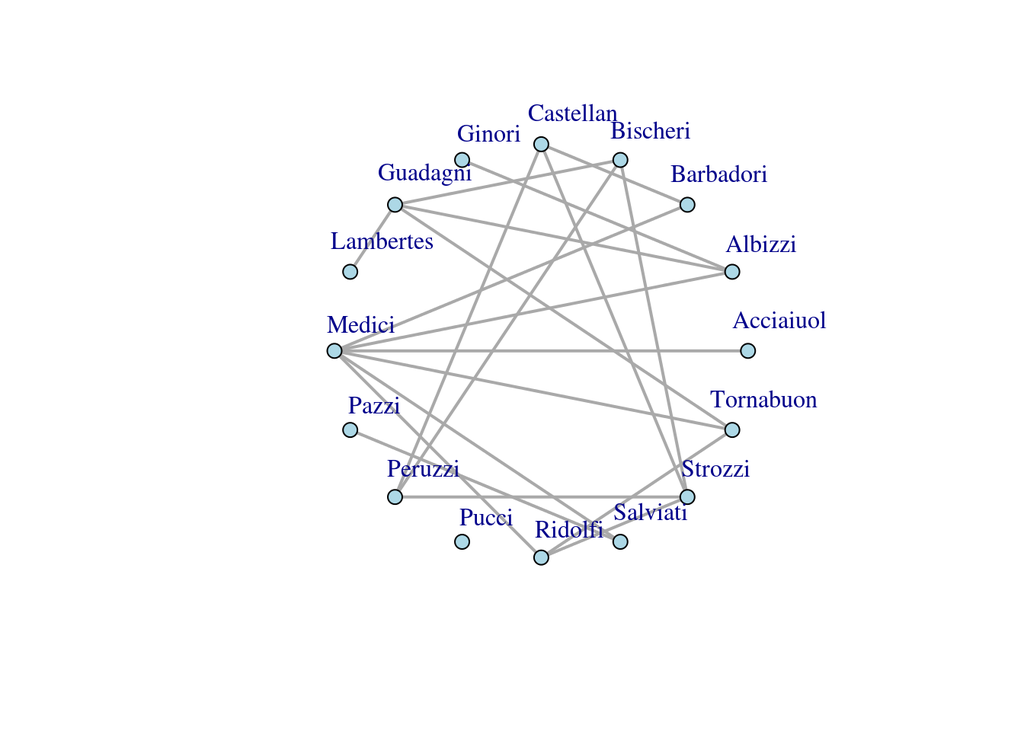

```r
plot(florentine, layout = layout.circle)
```

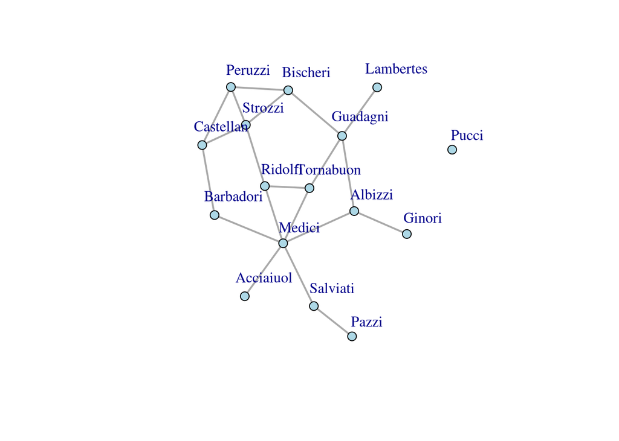

```r
plot(florentine, layout = layout.fruchterman.reingold)
```

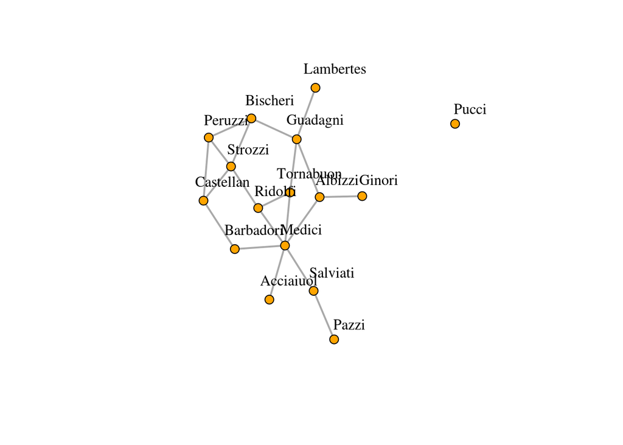

```r
plot(florentine, layout = layout.kamada.kawai,
     vertex.color = "orange",              # overrides pre-specified parameters
     vertex.label.color = "black")
```

### Меры центральности

Вспомним о различных мерах центральности – посчитаем, сколько брачных связей связывает семейство Медичи с остальными

```r
degree(florentine, v = "Medici")
```

```
## Medici
##      6
```

Что можно сказать о других семьях?

```r
degree(florentine)
```

```
## Acciaiuol   Albizzi Barbadori  Bischeri Castellan    Ginori  Guadagni
##         1         3         2         3         3         1         4
## Lambertes    Medici     Pazzi   Peruzzi     Pucci   Ridolfi  Salviati
##         1         6         1         3         0         3         2
##   Strozzi Tornabuon
##         4         3
```

Для более удобного представления мы можем изменить размер вершин таким образом, чтобы он отражал степень вершины

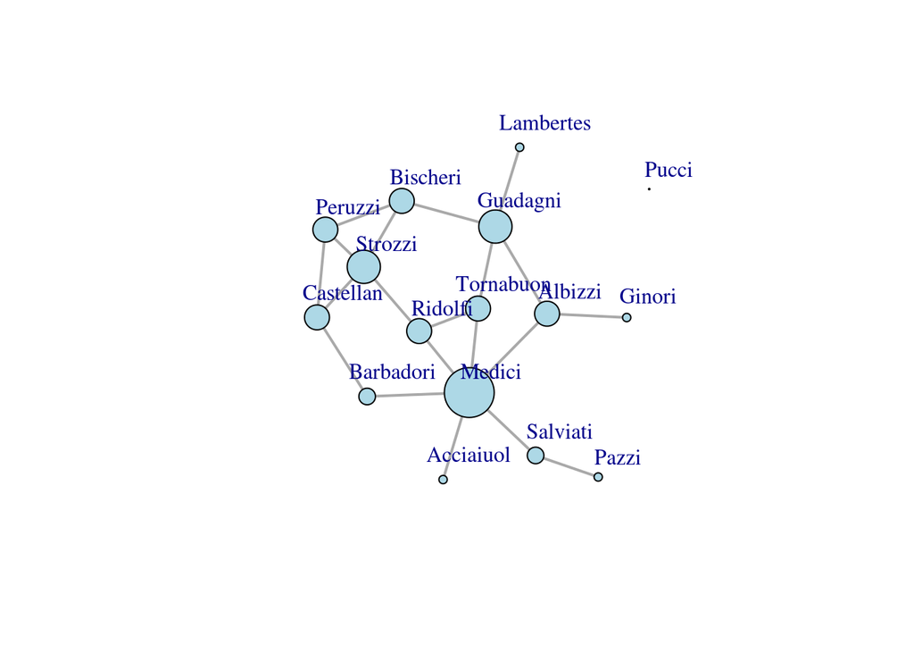

```r
plot(florentine, vertex.size = degree(florentine)*5)
```

… или показать это цветом

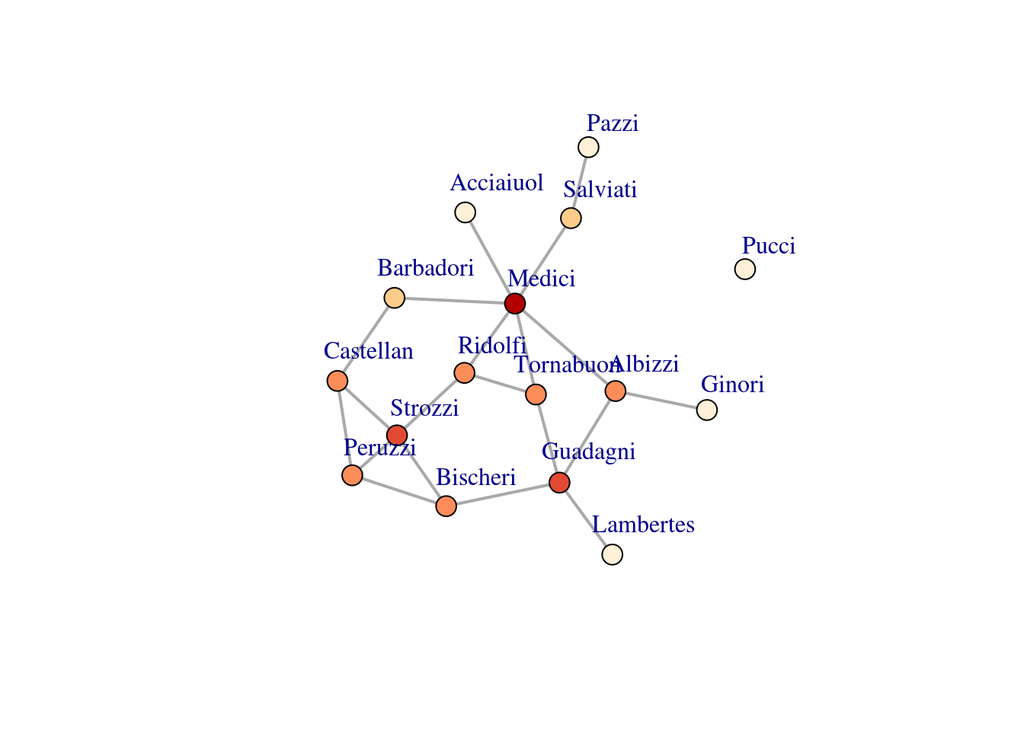

```r
plot(florentine,
     vertex.color = cut(degree(florentine),5),
     palette = sequential_pal(5),
     vertex.size = 10)
```

- Какие выводы можно сделать из данного графа?
- замените степень на битвинность. Как изменятся выводы?

Рассмотрим другие меры центральности.

#### Центральность по близости

“Быстро достижимые вершины”

```r
closeness(florentine)
```

```
##   Acciaiuol     Albizzi   Barbadori    Bischeri   Castellan      Ginori
## 0.018518519 0.022222222 0.020833333 0.019607843 0.019230769 0.017241379
##    Guadagni   Lambertes      Medici       Pazzi     Peruzzi       Pucci
## 0.021739130 0.016949153 0.024390244 0.015384615 0.018518519 0.004166667
##     Ridolfi    Salviati     Strozzi   Tornabuon
## 0.022727273 0.019230769 0.020833333 0.022222222
```

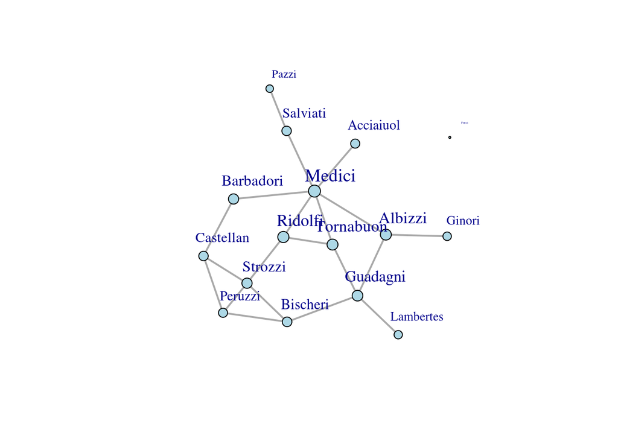

```r
plot(florentine, vertex.size = closeness(florentine)*400,
     vertex.label.cex = closeness(florentine)*50)
```

#### PageRank

“Важны соседи”

Вершина более важна, если она связана с более важными вершинами (eigenvector centrality)

Разрабатывался как инструмент для ранжирования веб-страниц (Google PageRank). Если на странице A есть ссылка на страницу B, это значит, что автор А считает, что источник В полезен. Т.е. ссылка от А добавляет репутацию В, но А тоже бывают разные…

```r
page_rank(florentine)$vector
```

```
##  Acciaiuol    Albizzi  Barbadori   Bischeri  Castellan     Ginori
## 0.03035390 0.07833886 0.04980296 0.06818000 0.06864374 0.03209700
##   Guadagni  Lambertes     Medici      Pazzi    Peruzzi      Pucci
## 0.09742360 0.03060350 0.14437347 0.03569690 0.06720328 0.00990099
##    Ridolfi   Salviati    Strozzi  Tornabuon
## 0.06888541 0.06069627 0.08722618 0.07057395
```

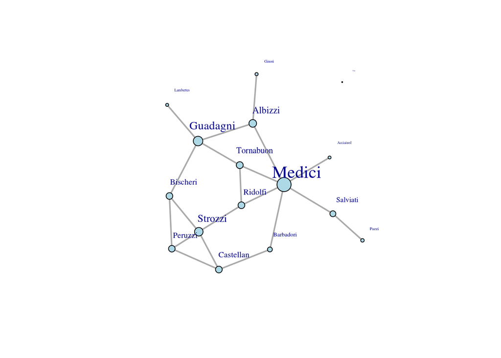

```r
plot(florentine, vertex.size = page_rank(florentine)$vector*100,
     vertex.label.cex = page_rank(florentine)$vector*10)
```

### Выявление сообществ

Модулярность = разность между долей ребер внутри сообщества и ожидаемой доли связей, если бы ребра были размещены случайно. Является мерой качества разделения на сообщества.

#### Fast-Greedy

Иерархический подход. Первоначально каждая вершина представляет собой отдельное сообщество. Сообщества объединяются таким образом, чтобы это привело к наибольшему возрастанию модулярности. Останавливаемся, когда нет следующего шага, увеличивающего модулярность.

```r
fgcommune <- fastgreedy.community(florentine)
membership(fgcommune) ## assigning nodes to communities
```

```
## Acciaiuol   Albizzi Barbadori  Bischeri Castellan    Ginori  Guadagni
##         1         2         3         3         3         2         2
## Lambertes    Medici     Pazzi   Peruzzi     Pucci   Ridolfi  Salviati
##         2         1         1         3         4         1         1
##   Strozzi Tornabuon
##         3         1
```

```r
modularity(fgcommune)
```

```
## [1] 0.39875
```

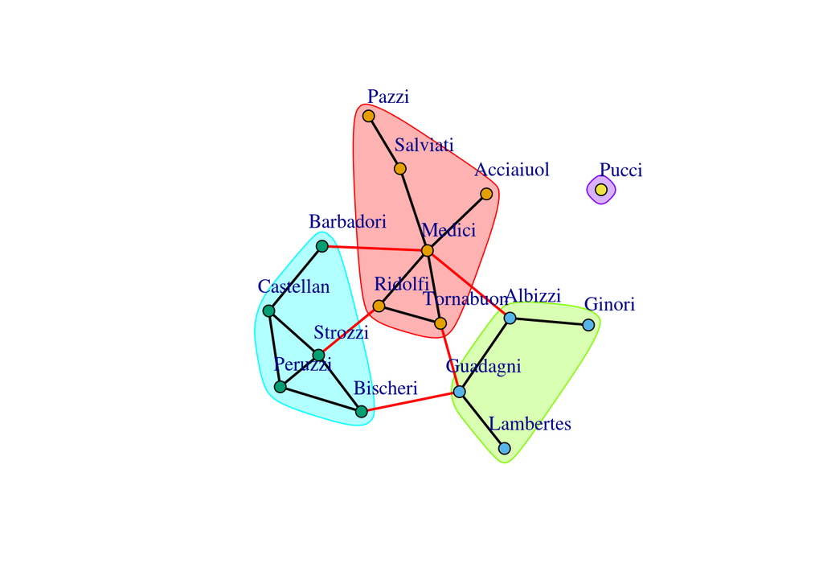

```r
plot(fgcommune, florentine)
```

График без затененных областей

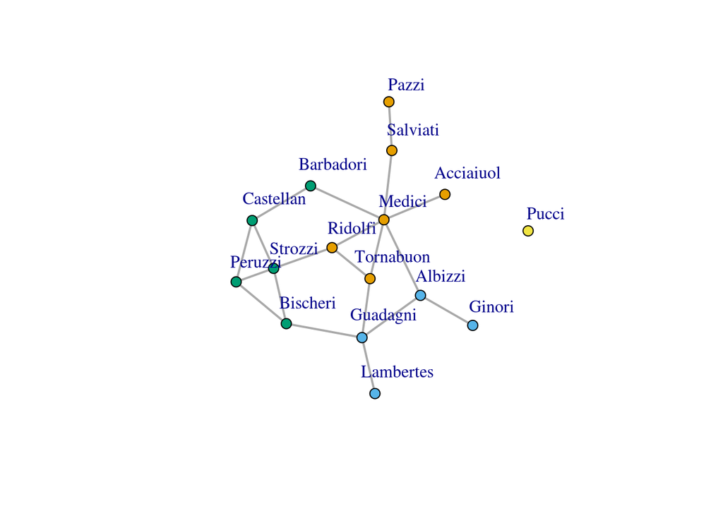

```r
plot(florentine, vertex.color = membership(fgcommune))
```

Дендрограмма

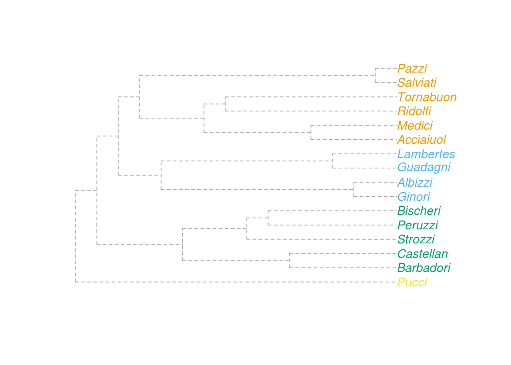

```r
dendPlot(fgcommune)
```

#### Walktrap

Подход, основанный на случайных путях. Основная идея – если случайно “блуждать” по графу, то больше шансов, что ваш путь будет чаще оставаться внутри сообщества и только иногда выходить за его пределы.

```r
wtcommune <- walktrap.community(florentine)
membership(wtcommune) ## assigning nodes to communities
```

```
## Acciaiuol   Albizzi Barbadori  Bischeri Castellan    Ginori  Guadagni
##         2         1         3         3         3         1         1
## Lambertes    Medici     Pazzi   Peruzzi     Pucci   Ridolfi  Salviati
##         1         2         4         3         5         2         4
##   Strozzi Tornabuon
##         3         2
```

```r
modularity(wtcommune)
```

```
## [1] 0.3975
```

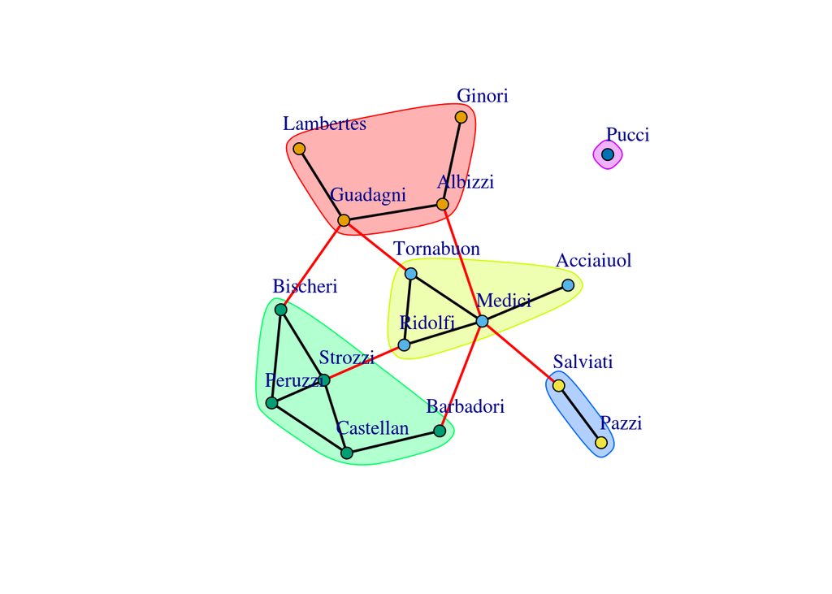

```r
plot(wtcommune, florentine)
```

Другие алгоритмы в `igraph`

- label.propagation.community
- leading.eigenvector.community
- multilevel.community
- optimal.community
- spinglass.community
- infomap.community

### Ваша очередь

Исследуйте другую часть данных про семьи Флоренции – теперь с финансовыми связями.

```r
adjFlorenceFinance <- read.csv("~/shared/minor2_2016/2-datatech/lab03-igraph/florentineFamilyFinance.csv")
rownames(adjFlorenceFinance) <- names(adjFlorenceFinance)

adjFlorenceFinance <- as.matrix.data.frame(adjFlorenceFinance)
```

```r
pander::pandoc.table(adjFlorenceFinance, split.tables = Inf)
```

|  | Acciaiuol | Albizzi | Barbadori | Bischeri | Castellan | Ginori | Guadagni | Lambertes | Medici | Pazzi | Peruzzi | Pucci | Ridolfi | Salviati | Strozzi | Tornabuon |
| --- | --- | --- | --- | --- | --- | --- | --- | --- | --- | --- | --- | --- | --- | --- | --- | --- |
| **Acciaiuol** | 0 | 0 | 0 | 0 | 0 | 0 | 0 | 0 | 0 | 0 | 0 | 0 | 0 | 0 | 0 | 0 |
| **Albizzi** | 0 | 0 | 0 | 0 | 0 | 0 | 0 | 0 | 0 | 0 | 0 | 0 | 0 | 0 | 0 | 0 |
| **Barbadori** | 0 | 0 | 0 | 0 | 1 | 1 | 0 | 0 | 1 | 0 | 1 | 0 | 0 | 0 | 0 | 0 |
| **Bischeri** | 0 | 0 | 0 | 0 | 0 | 0 | 1 | 1 | 0 | 0 | 1 | 0 | 0 | 0 | 0 | 0 |
| **Castellan** | 0 | 0 | 1 | 0 | 0 | 0 | 0 | 1 | 0 | 0 | 1 | 0 | 0 | 0 | 0 | 0 |
| **Ginori** | 0 | 0 | 1 | 0 | 0 | 0 | 0 | 0 | 1 | 0 | 0 | 0 | 0 | 0 | 0 | 0 |
| **Guadagni** | 0 | 0 | 0 | 1 | 0 | 0 | 0 | 1 | 0 | 0 | 0 | 0 | 0 | 0 | 0 | 0 |
| **Lambertes** | 0 | 0 | 0 | 1 | 1 | 0 | 1 | 0 | 0 | 0 | 1 | 0 | 0 | 0 | 0 | 0 |
| **Medici** | 0 | 0 | 1 | 0 | 0 | 1 | 0 | 0 | 0 | 1 | 0 | 0 | 0 | 1 | 0 | 1 |
| **Pazzi** | 0 | 0 | 0 | 0 | 0 | 0 | 0 | 0 | 1 | 0 | 0 | 0 | 0 | 0 | 0 | 0 |
| **Peruzzi** | 0 | 0 | 1 | 1 | 1 | 0 | 0 | 1 | 0 | 0 | 0 | 0 | 0 | 0 | 0 | 0 |
| **Pucci** | 0 | 0 | 0 | 0 | 0 | 0 | 0 | 0 | 0 | 0 | 0 | 0 | 0 | 0 | 0 | 0 |
| **Ridolfi** | 0 | 0 | 0 | 0 | 0 | 0 | 0 | 0 | 0 | 0 | 0 | 0 | 0 | 0 | 0 | 0 |
| **Salviati** | 0 | 0 | 0 | 0 | 0 | 0 | 0 | 0 | 1 | 0 | 0 | 0 | 0 | 0 | 0 | 0 |
| **Strozzi** | 0 | 0 | 0 | 0 | 0 | 0 | 0 | 0 | 0 | 0 | 0 | 0 | 0 | 0 | 0 | 0 |
| **Tornabuon** | 0 | 0 | 0 | 0 | 0 | 0 | 0 | 0 | 1 | 0 | 0 | 0 | 0 | 0 | 0 | 0 |

- Матрица соответствует направленному или ненаправленному графу?
- Создайте граф, нарисуйте его
- Измените какой-либо графический параметр (цвет, размер, форму,…)
- Сравните разные меры центральности. Какие выводы можно сделать?
- Сравните разные алгоритмы выделения сообществ. Какие выводы можно сделать?